# Evidencia 2

```r
virus_tree <- ladderize(virus_tree)
```

#Esta gráfica nos permite comparar las diversas variantes de una manera más visual, pues se usa un cuadrito blanco si la variantes son muy similares entre sí, un cuadro gris en el caso que sean mas o menos parecidas, y un cuadro negro si existe una diferencia considerable entre las variantes. Estas gráficas coinciden con la gráfica anterior, pues muestra que las variantes MW453103, MW850639, MW966601, MZ169911, OM685375, OM958567, son muy similares, pues en las intersecciones hay cuadros blancos, y en la gráfica anterior, salen agrupadas estas variantes, pues tenían una cantidad de bases muy similares.

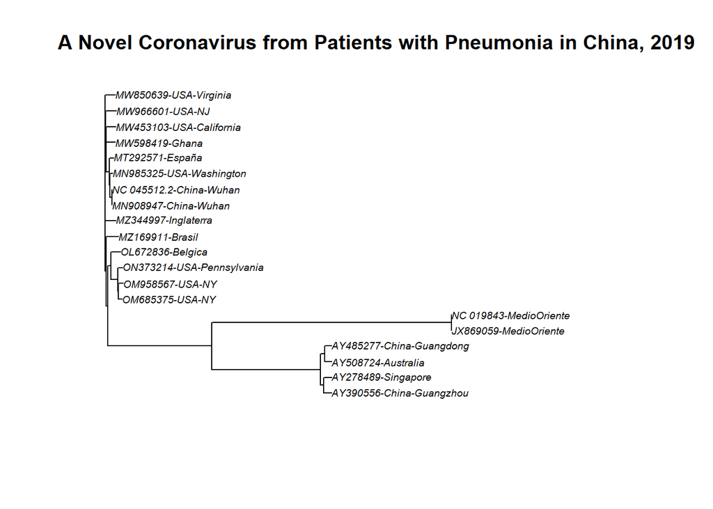

```r
plot(virus_tree, cex = 0.6)
title("A Novel Coronavirus from Patients with Pneumonia in China, 2019")
```

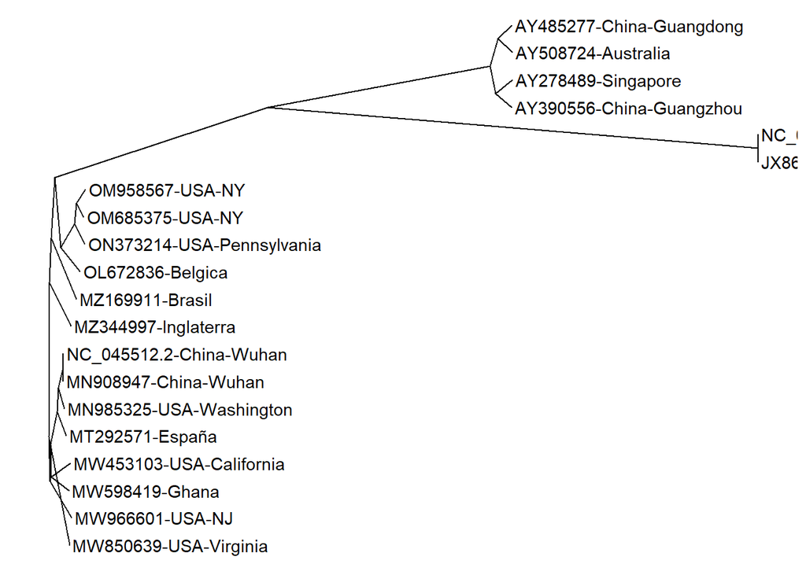

```r
ggtree(virus_tree, layout="slanted") + geom_tiplab()
```

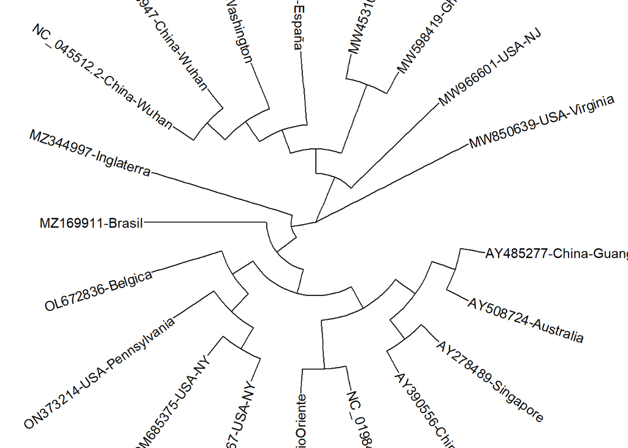

```r
ggtree(virus_tree, branch.length='none', layout='circular')+ geom_tiplab()
```

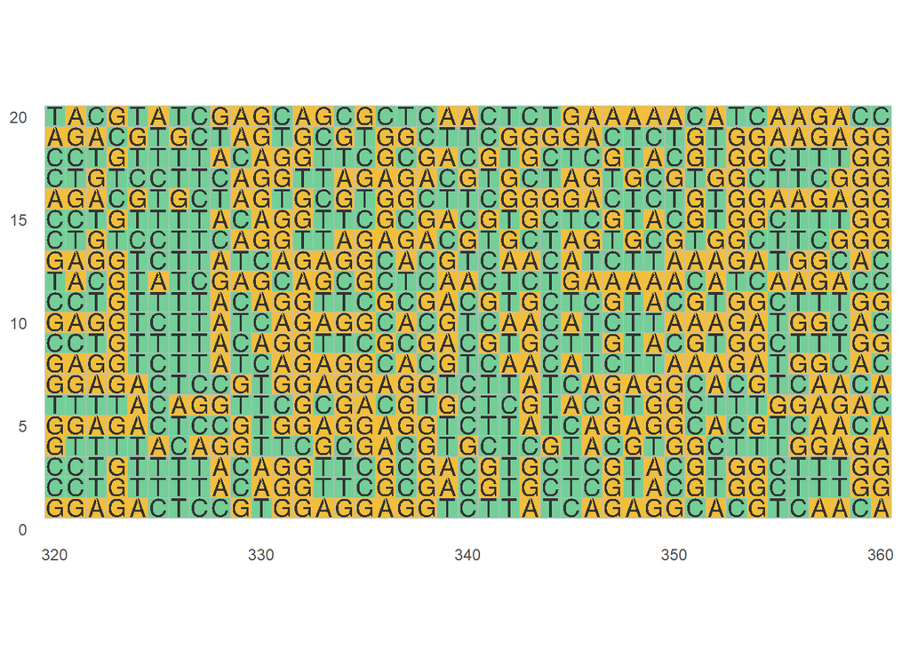

```r
if (!require("BiocManager", quietly = TRUE))
  install.packages("BiocManager")
BiocManager::install("ggmsa")
library("ggmsa")
ggmsa(virus_seq_not_align, 320, 360, color = "Chemistry_AA")
```

#Esta gráfica nos permite analizar las bases de una manera más visual, para que sea más sencillo comparar las variantes descendientes del Coronavirus y de esta manera ver que tan parecidas son.

#Link del video:

https://youtu.be/nZjUXPcgAqI